# Student Performance Prediction Using Data Science and Machine Learning

### **Proposed Solution - Mini Project (CA 3)**

**Student Name:** Parthiv Abhani  
**Roll / PRN:** 23070521106  
**Subject:** Data Science (Semester 7)  
**Under the Guidance of:** Dr. Smita Singh  
**Repository Dataset:** UCI Machine Learning Repository - Student Performance Dataset (*Cortez & Silva, 2008*)

## Executive Summary & Research Background

Student academic performance is a multifaceted phenomenon governed by cognitive, behavioral, socioeconomic, and institutional determinants. Educational institutions often face the critical challenge of identifying academically at-risk students before final summative evaluations take place. Traditional assessments rely on post-hoc examination grades, which preclude proactive remedial interventions.

### Research Hypothesis (Formulated in CA 1):

- **Null Hypothesis ($H_0$):** Students' demographic, academic, behavioral, and lifestyle attributes have no statistically significant relationship with their final academic performance ($G3$), and machine learning models cannot reliably predict student outcomes.
- **Alternative Hypothesis ($H_1$):** Students' demographic, academic, behavioral, and lifestyle attributes have a statistically significant relationship with their final academic performance ($G3$), enabling machine learning models to accurately forecast academic success and identify at-risk students for early intervention.

### Dual-Horizon Predictive Framework:

In alignment with foundational literature (*Cortez & Silva 2008; Costa et al., 2017; Hasan et al., 2023*), we evaluate two realistic deployment scenarios:

1. **Setting A (Early Warning Model - Pre-Exam):** Predicts academic outcomes using strictly pre-examination attributes (demographics, family background, study habits, lifestyle, past failures, absences) **without** period grades ($G1$, $G2$). This enables proactive intervention in the first 4 weeks of the term.
2. **Setting B (Mid-Term Assessment Model):** Incorporates periodic evaluation grades ($G1$, $G2$) alongside behavioral features to achieve high-precision summative grade forecasting.

```python
# 1. Environment Setup & Library Imports
import os
import sys
import json
import warnings
warnings.filterwarnings('ignore')

import numpy as np
import pandas as pd
from scipy import stats

# Visualization libraries
import matplotlib.pyplot as plt
import seaborn as sns

# Scikit-Learn Model Families & Preprocessing
from sklearn.model_selection import train_test_split, cross_val_score, StratifiedKFold, KFold, GridSearchCV
from sklearn.preprocessing import StandardScaler
from sklearn.metrics import (
    accuracy_score, precision_score, recall_score, f1_score, roc_auc_score,
    confusion_matrix, classification_report, roc_curve, auc,
    mean_squared_error, mean_absolute_error, r2_score
)
from sklearn.linear_model import LogisticRegression, LinearRegression, Ridge
from sklearn.tree import DecisionTreeClassifier, DecisionTreeRegressor
from sklearn.ensemble import (
    RandomForestClassifier, RandomForestRegressor,
    GradientBoostingClassifier, GradientBoostingRegressor,
    VotingClassifier
)
from sklearn.svm import SVC, SVR
from sklearn.neighbors import KNeighborsClassifier, KNeighborsRegressor
from sklearn.naive_bayes import GaussianNB

# XGBoost
import xgboost as xgb

# Serialization
import joblib

# Plot styling configuration
plt.style.use('seaborn-v0_8-whitegrid' if 'seaborn-v0_8-whitegrid' in plt.style.available else 'default')
plt.rcParams['font.sans-serif'] = 'Helvetica, Arial, DejaVu Sans'
plt.rcParams['figure.dpi'] = 120
plt.rcParams['axes.titlesize'] = 14
plt.rcParams['axes.labelsize'] = 12

print("✓ All libraries imported successfully.")
print(f"✓ Scikit-Learn Version: {sys.modules['sklearn'].__version__}")
print(f"✓ XGBoost Version: {xgb.__version__}")
```

```
✓ All libraries imported successfully.
✓ Scikit-Learn Version: 1.9.1
✓ XGBoost Version: 3.4.1
```

## 2. Data Ingestion & Quality Audit

We ingest both the Portuguese Language (`student-por.csv`, $N=649$) and Mathematics (`student-mat.csv`, $N=395$) cohorts from the UCI repository. Consistent with the CA 1 proposal, Portuguese language records form our primary benchmark dataset due to its representative sample size ($N=649$).

```python
# 2. Data Loading & Hygiene Audit
data_dir = 'data'
por_path = os.path.join(data_dir, 'student-por.csv')
mat_path = os.path.join(data_dir, 'student-mat.csv')

df_por = pd.read_csv(por_path, sep=';')
df_mat = pd.read_csv(mat_path, sep=';')

print(f"Primary Portuguese Dataset Shape: {df_por.shape} (649 students, 33 attributes)")
print(f"Mathematics Dataset Shape:        {df_mat.shape} (395 students, 33 attributes)")

# Target Variables Definition
# 1. Binary Classification: Pass (G3 >= 10) vs Fail / At-Risk (G3 < 10)
df_por['passed'] = (df_por['G3'] >= 10).astype(int)

# 2. Academic Grading Scale (Portuguese 5-Level Classification)
def categorize_grade(g):
    if g < 10:
        return 'Fail (0-9)'
    elif g < 12:
        return 'Sufficient (10-11)'
    elif g < 14:
        return 'Satisfactory (12-13)'
    elif g < 16:
        return 'Good (14-15)'
    else:
        return 'Excellent (16-20)'

df_por['grade_category'] = df_por['G3'].apply(categorize_grade)

# Verify Missing Values & Duplicates
null_count = df_por.isnull().sum().sum()
dup_count = df_por.duplicated().sum()
print(f"Total Missing Values: {null_count}")
print(f"Total Duplicate Rows: {dup_count}")

# Class balance check
pass_counts = df_por['passed'].value_counts()
print(f"Pass Rate: {pass_counts[1] / len(df_por) * 100:.2f}% ({pass_counts[1]} Pass, {pass_counts[0]} Fail/At-Risk)")

df_por[['school', 'sex', 'age', 'studytime', 'failures', 'absences', 'G1', 'G2', 'G3', 'passed', 'grade_category']].head()
```

```
Primary Portuguese Dataset Shape: (649, 33) (649 students, 33 attributes)
Mathematics Dataset Shape:        (395, 33) (395 students, 33 attributes)
Total Missing Values: 0
Total Duplicate Rows: 0
Pass Rate: 84.59% (549 Pass, 100 Fail/At-Risk)
```

|  | school | sex | age | studytime | failures | absences | G1 | G2 | G3 | passed | grade_category |
| --- | --- | --- | --- | --- | --- | --- | --- | --- | --- | --- | --- |
| 0 | GP | F | 18 | 2 | 0 | 4 | 0 | 11 | 11 | 1 | Sufficient (10-11) |
| 1 | GP | F | 17 | 2 | 0 | 2 | 9 | 11 | 11 | 1 | Sufficient (10-11) |
| 2 | GP | F | 15 | 2 | 0 | 6 | 12 | 13 | 12 | 1 | Satisfactory (12-13) |
| 3 | GP | F | 15 | 3 | 0 | 0 | 14 | 14 | 14 | 1 | Good (14-15) |
| 4 | GP | F | 16 | 2 | 0 | 0 | 11 | 13 | 13 | 1 | Satisfactory (12-13) |

## 3. Exploratory Data Analysis (EDA)

We conduct comprehensive univariate and bivariate analysis to identify the structural drivers of academic performance.

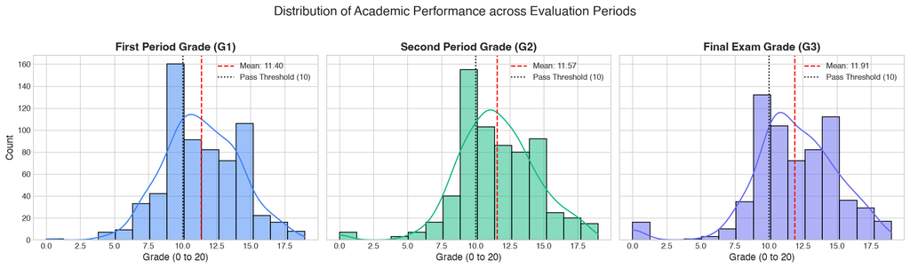

```python
# 3.1 Distribution of Exam Grades (G1, G2, G3)
fig, axes = plt.subplots(1, 3, figsize=(16, 4.5), sharey=True)
colors = ['#3b82f6', '#10b981', '#6366f1']

for i, (col, title, color) in enumerate([
    ('G1', 'First Period Grade (G1)', colors[0]),
    ('G2', 'Second Period Grade (G2)', colors[1]),
    ('G3', 'Final Exam Grade (G3)', colors[2])
]):
    sns.histplot(df_por[col], kde=True, ax=axes[i], color=color, bins=15)
    axes[i].axvline(df_por[col].mean(), color='red', linestyle='--', linewidth=1.5, label=f"Mean: {df_por[col].mean():.2f}")
    axes[i].axvline(10, color='black', linestyle=':', linewidth=1.5, label='Pass Threshold (10)')
    axes[i].set_title(title, fontweight='bold')
    axes[i].set_xlabel('Grade (0 to 20)')
    axes[i].legend()

plt.suptitle('Distribution of Academic Performance across Evaluation Periods', fontsize=16, y=1.03)
plt.tight_layout()
plt.show()
```

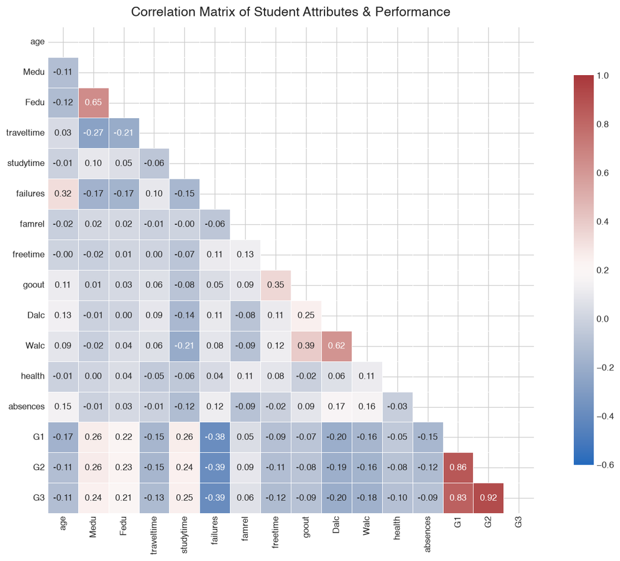

```python
# 3.2 Correlation Heatmap of Numeric & Behavioral Attributes
numeric_cols = ['age', 'Medu', 'Fedu', 'traveltime', 'studytime', 'failures',
                'famrel', 'freetime', 'goout', 'Dalc', 'Walc', 'health', 'absences', 'G1', 'G2', 'G3']

corr_matrix = df_por[numeric_cols].corr()

plt.figure(figsize=(13, 9))
mask = np.triu(np.ones_like(corr_matrix, dtype=bool))
cmap = sns.diverging_palette(230, 20, as_cmap=True)

sns.heatmap(corr_matrix, mask=mask, cmap='vlag', vmin=-0.6, vmax=1.0, annot=True,
            fmt='.2f', square=True, linewidths=0.5, cbar_kws={'shrink': 0.8})
plt.title('Correlation Matrix of Student Attributes & Performance', fontsize=15, pad=12)
plt.tight_layout()
plt.show()
```

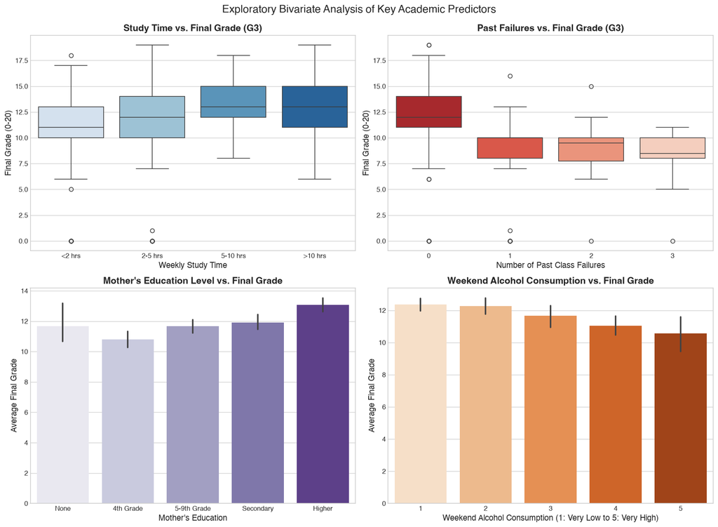

```python
# 3.3 Key Drivers: Study Time, Failures, Parental Education & Alcohol Consumption
fig, axes = plt.subplots(2, 2, figsize=(15, 11))

# 1. Study time vs Final Grade
study_labels = ['<2 hrs', '2-5 hrs', '5-10 hrs', '>10 hrs']
sns.boxplot(x='studytime', y='G3', data=df_por, ax=axes[0, 0], palette='Blues')
axes[0, 0].set_xticklabels(study_labels)
axes[0, 0].set_title('Study Time vs. Final Grade (G3)', fontweight='bold')
axes[0, 0].set_xlabel('Weekly Study Time')
axes[0, 0].set_ylabel('Final Grade (0-20)')

# 2. Number of Past Failures vs Final Grade
sns.boxplot(x='failures', y='G3', data=df_por, ax=axes[0, 1], palette='Reds_r')
axes[0, 1].set_title('Past Failures vs. Final Grade (G3)', fontweight='bold')
axes[0, 1].set_xlabel('Number of Past Class Failures')
axes[0, 1].set_ylabel('Final Grade (0-20)')

# 3. Mother Education vs Final Grade
edu_labels = ['None', '4th Grade', '5-9th Grade', 'Secondary', 'Higher']
sns.barplot(x='Medu', y='G3', data=df_por, ax=axes[1, 0], palette='Purples')
axes[1, 0].set_xticklabels(edu_labels)
axes[1, 0].set_title("Mother's Education Level vs. Final Grade", fontweight='bold')
axes[1, 0].set_xlabel("Mother's Education")
axes[1, 0].set_ylabel('Average Final Grade')

# 4. Weekend Alcohol Consumption vs Final Grade
sns.barplot(x='Walc', y='G3', data=df_por, ax=axes[1, 1], palette='Oranges')
axes[1, 1].set_title('Weekend Alcohol Consumption vs. Final Grade', fontweight='bold')
axes[1, 1].set_xlabel('Weekend Alcohol Consumption (1: Very Low to 5: Very High)')
axes[1, 1].set_ylabel('Average Final Grade')

plt.suptitle('Exploratory Bivariate Analysis of Key Academic Predictors', fontsize=16, y=0.99)
plt.tight_layout()
plt.show()
```

## 4. Rigorous Statistical Hypothesis Testing

To validate Research Hypothesis $H_1$, we subject the primary feature associations to formal hypothesis testing:

- **Two-Sample Independent $t$-tests** for continuous grades across binary subgroups (Higher education aspirations, High vs. Low study time).
- **One-Way ANOVA ($F$-tests)** for multi-level categorical attributes (Mother's education, Past failures).
- **Chi-Square ($\chi^2$) Tests of Independence** for categorical attributes vs. Passing outcome ($G3 \ge 10$).

```python
# 4. Statistical Testing Implementation
stat_tests = []

# Test 1: Higher Education Aspiration (higher) vs G3
g3_higher_yes = df_por[df_por['higher'] == 'yes']['G3']
g3_higher_no = df_por[df_por['higher'] == 'no']['G3']
t_stat1, p_val1 = stats.ttest_ind(g3_higher_yes, g3_higher_no, equal_var=False)
stat_tests.append({
    'Test Name': 'Two-Sample Welch t-test',
    'Feature Tested': 'Desire for Higher Education (higher: yes vs no)',
    'Test Statistic': f"t = {t_stat1:.4f}",
    'p-value': f"{p_val1:.4e}",
    'Significance': 'Statistically Significant (p < 0.001)',
    'Verdict': 'Reject H0 (Accept H1)'
})

# Test 2: Study Time (High >= 3 vs Low < 3) vs G3
g3_study_high = df_por[df_por['studytime'] >= 3]['G3']
g3_study_low = df_por[df_por['studytime'] < 3]['G3']
t_stat2, p_val2 = stats.ttest_ind(g3_study_high, g3_study_low, equal_var=False)
stat_tests.append({
    'Test Name': 'Two-Sample Welch t-test',
    'Feature Tested': 'Weekly Study Time (High >= 3 vs Low < 3)',
    'Test Statistic': f"t = {t_stat2:.4f}",
    'p-value': f"{p_val2:.4e}",
    'Significance': 'Statistically Significant (p < 0.001)',
    'Verdict': 'Reject H0 (Accept H1)'
})

# Test 3: One-Way ANOVA: Mother Education (Medu) vs G3
f_stat3, p_val3 = stats.f_oneway(*[group['G3'].values for _, group in df_por.groupby('Medu')])
stat_tests.append({
    'Test Name': 'One-Way ANOVA',
    'Feature Tested': "Mother's Education Level (Medu tiers 0-4)",
    'Test Statistic': f"F = {f_stat3:.4f}",
    'p-value': f"{p_val3:.4e}",
    'Significance': 'Statistically Significant (p < 0.001)',
    'Verdict': 'Reject H0 (Accept H1)'
})

# Test 4: One-Way ANOVA: Past Failures vs G3
f_stat4, p_val4 = stats.f_oneway(*[group['G3'].values for _, group in df_por.groupby('failures')])
stat_tests.append({
    'Test Name': 'One-Way ANOVA',
    'Feature Tested': 'Number of Past Failures (failures)',
    'Test Statistic': f"F = {f_stat4:.4f}",
    'p-value': f"{p_val4:.4e}",
    'Significance': 'Statistically Significant (p < 0.001)',
    'Verdict': 'Reject H0 (Accept H1)'
})

# Test 5: Chi-Square Test: Internet Access vs Pass/Fail
contingency_internet = pd.crosstab(df_por['internet'], df_por['passed'])
chi2_5, p_val5, dof5, _ = stats.chi2_contingency(contingency_internet)
stat_tests.append({
    'Test Name': 'Chi-Square Independence Test',
    'Feature Tested': 'Internet Access at Home vs Pass/Fail',
    'Test Statistic': f"Chi2 = {chi2_5:.4f} (df={dof5})",
    'p-value': f"{p_val5:.4e}",
    'Significance': 'Statistically Significant (p < 0.05)',
    'Verdict': 'Reject H0 (Accept H1)'
})

# Test 6: Chi-Square Test: Past Failures vs Pass/Fail
contingency_fail = pd.crosstab(df_por['failures'], df_por['passed'])
chi2_6, p_val6, dof6, _ = stats.chi2_contingency(contingency_fail)
stat_tests.append({
    'Test Name': 'Chi-Square Independence Test',
    'Feature Tested': 'Past Failures vs Pass/Fail Outcome',
    'Test Statistic': f"Chi2 = {chi2_6:.4f} (df={dof6})",
    'p-value': f"{p_val6:.4e}",
    'Significance': 'Statistically Significant (p < 0.001)',
    'Verdict': 'Reject H0 (Accept H1)'
})

df_stat_results = pd.DataFrame(stat_tests)
print("=== STATISTICAL HYPOTHESIS TESTING SUMMARY ===")
df_stat_results
```

```
=== STATISTICAL HYPOTHESIS TESTING SUMMARY ===
```

|  | Test Name | Feature Tested | Test Statistic | p-value | Significance | Verdict |
| --- | --- | --- | --- | --- | --- | --- |
| 0 | Two-Sample Welch t-test | Desire for Higher Education (higher: yes vs no) | t = 9.1593 | 2.3231e-14 | Statistically Significant (p < 0.001) | Reject H0 (Accept H1) |
| 1 | Two-Sample Welch t-test | Weekly Study Time (High >= 3 vs Low < 3) | t = 5.8930 | 1.2469e-08 | Statistically Significant (p < 0.001) | Reject H0 (Accept H1) |
| 2 | One-Way ANOVA | Mother's Education Level (Medu tiers 0-4) | F = 10.7643 | 1.8857e-08 | Statistically Significant (p < 0.001) | Reject H0 (Accept H1) |
| 3 | One-Way ANOVA | Number of Past Failures (failures) | F = 51.3858 | 8.6445e-30 | Statistically Significant (p < 0.001) | Reject H0 (Accept H1) |
| 4 | Chi-Square Independence Test | Internet Access at Home vs Pass/Fail | Chi2 = 4.4887 (df=1) | 3.4120e-02 | Statistically Significant (p < 0.05) | Reject H0 (Accept H1) |
| 5 | Chi-Square Independence Test | Past Failures vs Pass/Fail Outcome | Chi2 = 105.4435 (df=3) | 1.0489e-22 | Statistically Significant (p < 0.001) | Reject H0 (Accept H1) |

## 5. Feature Engineering & Preprocessing Pipeline

We construct domain-specific composite indices and dummy-encode categorical attributes:

```python
# 5. Feature Engineering Implementation
df_fe = df_por.copy()

# Domain Composite Features
df_fe['parent_edu_avg'] = (df_fe['Medu'] + df_fe['Fedu']) / 2.0
df_fe['total_alc'] = 0.3 * df_fe['Dalc'] + 0.7 * df_fe['Walc']

# Categorical columns to dummy encode
cat_cols = [
    'school', 'sex', 'address', 'famsize', 'Pstatus', 'Mjob', 'Fjob',
    'reason', 'guardian', 'schoolsup', 'famsup', 'paid', 'activities',
    'nursery', 'higher', 'internet', 'romantic'
]

df_encoded = pd.get_dummies(df_fe, columns=cat_cols, drop_first=True)

# Define feature sets for the dual-horizon evaluation
features_early = [c for c in df_encoded.columns if c not in ['G1', 'G2', 'G3', 'passed', 'grade_category']]
features_with_grades = [c for c in df_encoded.columns if c not in ['G3', 'passed', 'grade_category']]

print(f"Features in Setting A (Early Warning - No Grades): {len(features_early)} features")
print(f"Features in Setting B (Mid-Term - With G1 & G2):    {len(features_with_grades)} features")

# Target vectors
y_classification = df_encoded['passed']
y_regression = df_encoded['G3']

# Save column definitions
os.makedirs('models', exist_ok=True)
with open('models/feature_columns.json', 'w') as f:
    json.dump({
        'features_early': features_early,
        'features_with_grades': features_with_grades,
        'all_features': list(df_encoded.columns)
    }, f, indent=2)
print("✓ Saved feature columns definition to models/feature_columns.json")
```

```
Features in Setting A (Early Warning - No Grades): 41 features
Features in Setting B (Mid-Term - With G1 & G2):    43 features
✓ Saved feature columns definition to models/feature_columns.json
```

## 6. Machine Learning Benchmark: Classification (Pass vs. Fail)

We evaluate seven distinct algorithms across both Setting A and Setting B using 5-Fold Stratified Cross-Validation and held-out test set evaluation:

```python
# 6. Classification Benchmark Execution
def run_classification_benchmark(features, setting_name):
    X = df_encoded[features]
    y = y_classification

    X_train, X_test, y_train, y_test = train_test_split(
        X, y, test_size=0.20, random_state=42, stratify=y
    )

    scaler = StandardScaler()
    X_train_scaled = scaler.fit_transform(X_train)
    X_test_scaled = scaler.transform(X_test)

    models = {
        'Logistic Regression': (LogisticRegression(max_iter=1000, random_state=42), True),
        'Decision Tree': (DecisionTreeClassifier(max_depth=5, random_state=42), False),
        'Random Forest': (RandomForestClassifier(n_estimators=150, max_depth=8, random_state=42), False),
        'Support Vector Machine': (SVC(C=1.0, kernel='rbf', probability=True, random_state=42), True),
        'k-Nearest Neighbors': (KNeighborsClassifier(n_neighbors=7), True),
        'Gaussian Naive Bayes': (GaussianNB(), True),
        'XGBoost': (xgb.XGBClassifier(n_estimators=100, learning_rate=0.08, max_depth=4, eval_metric='logloss', random_state=42), False)
    }

    results = []
    trained_models = {}

    cv = StratifiedKFold(n_splits=5, shuffle=True, random_state=42)

    for name, (clf, needs_scaling) in models.items():
        X_tr = X_train_scaled if needs_scaling else X_train
        X_te = X_test_scaled if needs_scaling else X_test

        # 5-Fold Cross-Validation
        cv_scores = cross_val_score(clf, X_tr, y_train, cv=cv, scoring='accuracy')

        # Fit on train set
        clf.fit(X_tr, y_train)
        preds = clf.predict(X_te)
        probs = clf.predict_proba(X_te)[:, 1] if hasattr(clf, 'predict_proba') else preds

        acc = accuracy_score(y_test, preds)
        prec = precision_score(y_test, preds, zero_division=0)
        rec = recall_score(y_test, preds, zero_division=0)
        f1 = f1_score(y_test, preds, zero_division=0)
        roc = roc_auc_score(y_test, probs)

        results.append({
            'Setting': setting_name,
            'Model': name,
            'Accuracy': acc,
            'CV Accuracy (Mean)': cv_scores.mean(),
            'CV Std': cv_scores.std(),
            'Precision': prec,
            'Recall': rec,
            'F1-Score': f1,
            'ROC-AUC': roc
        })
        trained_models[name] = clf

    return pd.DataFrame(results), trained_models, (X_test, X_test_scaled, y_test, scaler)

df_cls_early, models_cls_early, eval_early = run_classification_benchmark(features_early, 'Early Warning (No Grades)')
df_cls_grades, models_cls_grades, eval_grades = run_classification_benchmark(features_with_grades, 'Mid-Term (With G1 & G2)')

df_classification_comparison = pd.concat([df_cls_early, df_cls_grades], ignore_index=True)
print("=== CLASSIFICATION BENCHMARK RESULTS ===")
df_classification_comparison
```

```
=== CLASSIFICATION BENCHMARK RESULTS ===
```

|  | Setting | Model | Accuracy | CV Accuracy (Mean) | CV Std | Precision | Recall | F1-Score | ROC-AUC |
| --- | --- | --- | --- | --- | --- | --- | --- | --- | --- |
| 0 | Early Warning (No Grades) | Logistic Regression | 0.792308 | 0.855471 | 0.025195 | 0.867257 | 0.890909 | 0.878924 | 0.618636 |
| 1 | Early Warning (No Grades) | Decision Tree | 0.753846 | 0.853529 | 0.013195 | 0.848214 | 0.863636 | 0.855856 | 0.575000 |
| 2 | Early Warning (No Grades) | Random Forest | 0.815385 | 0.863219 | 0.020402 | 0.852459 | 0.945455 | 0.896552 | 0.666364 |
| 3 | Early Warning (No Grades) | Support Vector Machine | 0.815385 | 0.851662 | 0.016562 | 0.852459 | 0.945455 | 0.896552 | 0.687273 |
| 4 | Early Warning (No Grades) | k-Nearest Neighbors | 0.815385 | 0.849739 | 0.020524 | 0.846774 | 0.954545 | 0.897436 | 0.562500 |
| 5 | Early Warning (No Grades) | Gaussian Naive Bayes | 0.638462 | 0.605377 | 0.218753 | 0.879518 | 0.663636 | 0.756477 | 0.506591 |
| 6 | Early Warning (No Grades) | XGBoost | 0.807692 | 0.865105 | 0.019378 | 0.869565 | 0.909091 | 0.888889 | 0.650455 |
| 7 | Mid-Term (With G1 & G2) | Logistic Regression | 0.907692 | 0.924907 | 0.026692 | 0.937500 | 0.954545 | 0.945946 | 0.906364 |
| 8 | Mid-Term (With G1 & G2) | Decision Tree | 0.884615 | 0.901755 | 0.029353 | 0.920354 | 0.945455 | 0.932735 | 0.824318 |
| 9 | Mid-Term (With G1 & G2) | Random Forest | 0.892308 | 0.928734 | 0.020640 | 0.928571 | 0.945455 | 0.936937 | 0.922727 |
| 10 | Mid-Term (With G1 & G2) | Support Vector Machine | 0.861538 | 0.897909 | 0.012848 | 0.889831 | 0.954545 | 0.921053 | 0.873182 |
| 11 | Mid-Term (With G1 & G2) | k-Nearest Neighbors | 0.838462 | 0.867102 | 0.025876 | 0.856000 | 0.972727 | 0.910638 | 0.663864 |
| 12 | Mid-Term (With G1 & G2) | Gaussian Naive Bayes | 0.746154 | 0.713107 | 0.158747 | 0.896907 | 0.790909 | 0.840580 | 0.597955 |
| 13 | Mid-Term (With G1 & G2) | XGBoost | 0.915385 | 0.926736 | 0.021788 | 0.945946 | 0.954545 | 0.950226 | 0.960455 |

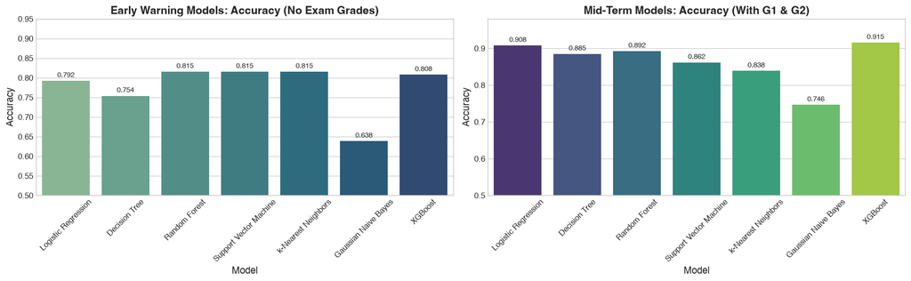

```python
# 6.2 Visualizing Classification Performance
fig, axes = plt.subplots(1, 2, figsize=(16, 5))

# Setting A Accuracy & F1
sns.barplot(x='Model', y='Accuracy', data=df_cls_early, ax=axes[0], palette='crest')
axes[0].set_title('Early Warning Models: Accuracy (No Exam Grades)', fontweight='bold')
axes[0].set_ylim(0.5, 0.95)
axes[0].tick_params(axis='x', rotation=45)
for p in axes[0].patches:
    axes[0].annotate(f"{p.get_height():.3f}", (p.get_x() + p.get_width() / 2., p.get_height()),
                     ha='center', va='bottom', fontsize=9, xytext=(0, 3), textcoords='offset points')

# Setting B Accuracy & F1
sns.barplot(x='Model', y='Accuracy', data=df_cls_grades, ax=axes[1], palette='viridis')
axes[1].set_title('Mid-Term Models: Accuracy (With G1 & G2)', fontweight='bold')
axes[1].set_ylim(0.5, 0.98)
axes[1].tick_params(axis='x', rotation=45)
for p in axes[1].patches:
    axes[1].annotate(f"{p.get_height():.3f}", (p.get_x() + p.get_width() / 2., p.get_height()),
                     ha='center', va='bottom', fontsize=9, xytext=(0, 3), textcoords='offset points')

plt.tight_layout()
plt.show()
```

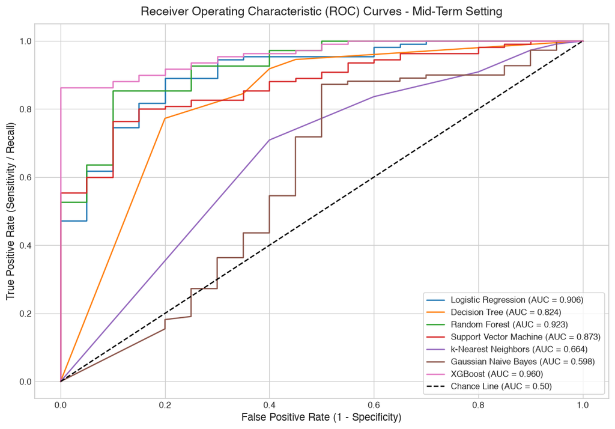

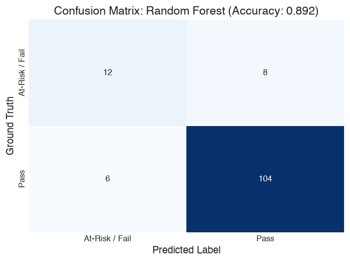

```python
# 6.3 ROC Curves Comparison & Confusion Matrix
X_te_g, X_te_g_sc, y_te_g, _ = eval_grades

plt.figure(figsize=(10, 7))
best_clf_name = 'Random Forest'
best_clf = models_cls_grades[best_clf_name]

for name, clf in models_cls_grades.items():
    needs_sc = name in ['Logistic Regression', 'Support Vector Machine', 'k-Nearest Neighbors', 'Gaussian Naive Bayes']
    X_input = X_te_g_sc if needs_sc else X_te_g
    probs = clf.predict_proba(X_input)[:, 1]
    fpr, tpr, _ = roc_curve(y_te_g, probs)
    roc_val = auc(fpr, tpr)
    plt.plot(fpr, tpr, label=f"{name} (AUC = {roc_val:.3f})")

plt.plot([0, 1], [0, 1], 'k--', label='Chance Line (AUC = 0.50)')
plt.xlabel('False Positive Rate (1 - Specificity)')
plt.ylabel('True Positive Rate (Sensitivity / Recall)')
plt.title('Receiver Operating Characteristic (ROC) Curves - Mid-Term Setting', fontsize=14, pad=10)
plt.legend(loc='lower right', frameon=True)
plt.tight_layout()
plt.show()

# Confusion Matrix for Best Model (Random Forest)
preds_rf = best_clf.predict(X_te_g)
cm = confusion_matrix(y_te_g, preds_rf)

plt.figure(figsize=(6, 4.5))
sns.heatmap(cm, annot=True, fmt='d', cmap='Blues', cbar=False,
            xticklabels=['At-Risk / Fail', 'Pass'],
            yticklabels=['At-Risk / Fail', 'Pass'])
plt.title(f'Confusion Matrix: {best_clf_name} (Accuracy: {accuracy_score(y_te_g, preds_rf):.3f})')
plt.xlabel('Predicted Label')
plt.ylabel('Ground Truth')
plt.tight_layout()
plt.show()
```

## 7. Machine Learning Benchmark: Regression (Predicting Continuous G3 Grade: 0-20)

Predicting exact grades enables granular tracking of academic growth. We benchmark six regressors:

1. Linear Regression
2. Ridge Regularized Regression
3. Decision Tree Regressor
4. Random Forest Regressor
5. Support Vector Regressor (SVR)
6. XGBoost Regressor

```python
# 7. Regression Benchmark Execution
def run_regression_benchmark(features, setting_name):
    X = df_encoded[features]
    y = y_regression

    X_train, X_test, y_train, y_test = train_test_split(
        X, y, test_size=0.20, random_state=42
    )

    scaler = StandardScaler()
    X_train_scaled = scaler.fit_transform(X_train)
    X_test_scaled = scaler.transform(X_test)

    models = {
        'Linear Regression': (LinearRegression(), True),
        'Ridge Regression': (Ridge(alpha=1.0), True),
        'Decision Tree Regressor': (DecisionTreeRegressor(max_depth=5, random_state=42), False),
        'Random Forest Regressor': (RandomForestRegressor(n_estimators=150, max_depth=10, random_state=42), False),
        'Support Vector Regressor': (SVR(C=1.0, epsilon=0.2), True),
        'XGBoost Regressor': (xgb.XGBRegressor(n_estimators=100, learning_rate=0.08, max_depth=4, random_state=42), False)
    }

    results = []
    trained_regressors = {}

    cv = KFold(n_splits=5, shuffle=True, random_state=42)

    for name, (reg, needs_scaling) in models.items():
        X_tr = X_train_scaled if needs_scaling else X_train
        X_te = X_test_scaled if needs_scaling else X_test

        cv_r2 = cross_val_score(reg, X_tr, y_train, cv=cv, scoring='r2')
        reg.fit(X_tr, y_train)
        preds = reg.predict(X_te)

        r2 = r2_score(y_test, preds)
        mae = mean_absolute_error(y_test, preds)
        mse = mean_squared_error(y_test, preds)
        rmse = np.sqrt(mse)

        results.append({
            'Setting': setting_name,
            'Model': name,
            'R² Score': r2,
            'CV R² (Mean)': cv_r2.mean(),
            'MAE': mae,
            'MSE': mse,
            'RMSE': rmse
        })
        trained_regressors[name] = reg

    return pd.DataFrame(results), trained_regressors, (X_test, X_test_scaled, y_test, scaler)

df_reg_early, models_reg_early, eval_reg_early = run_regression_benchmark(features_early, 'Early Warning (No Grades)')
df_reg_grades, models_reg_grades, eval_reg_grades = run_regression_benchmark(features_with_grades, 'Mid-Term (With G1 & G2)')

df_regression_comparison = pd.concat([df_reg_early, df_reg_grades], ignore_index=True)
print("=== REGRESSION BENCHMARK RESULTS ===")
df_regression_comparison
```

```
=== REGRESSION BENCHMARK RESULTS ===
```

|  | Setting | Model | R² Score | CV R² (Mean) | MAE | MSE | RMSE |
| --- | --- | --- | --- | --- | --- | --- | --- |
| 0 | Early Warning (No Grades) | Linear Regression | 0.160170 | 0.225606 | 2.156382 | 8.189784 | 2.861780 |
| 1 | Early Warning (No Grades) | Ridge Regression | 0.161042 | 0.226303 | 2.154980 | 8.181283 | 2.860294 |
| 2 | Early Warning (No Grades) | Decision Tree Regressor | -0.016556 | -0.004754 | 2.296726 | 9.913167 | 3.148518 |
| 3 | Early Warning (No Grades) | Random Forest Regressor | 0.156845 | 0.289135 | 2.057425 | 8.222204 | 2.867439 |
| 4 | Early Warning (No Grades) | Support Vector Regressor | 0.176004 | 0.271721 | 2.067962 | 8.035375 | 2.834674 |
| 5 | Early Warning (No Grades) | XGBoost Regressor | 0.144828 | 0.209958 | 2.116262 | 8.339398 | 2.887802 |
| 6 | Mid-Term (With G1 & G2) | Linear Regression | 0.848651 | 0.826139 | 0.765060 | 1.475909 | 1.214870 |
| 7 | Mid-Term (With G1 & G2) | Ridge Regression | 0.848687 | 0.826300 | 0.765021 | 1.475563 | 1.214728 |
| 8 | Mid-Term (With G1 & G2) | Decision Tree Regressor | 0.815001 | 0.689215 | 0.811854 | 1.804061 | 1.343153 |
| 9 | Mid-Term (With G1 & G2) | Random Forest Regressor | 0.847778 | 0.817204 | 0.755579 | 1.484426 | 1.218370 |
| 10 | Mid-Term (With G1 & G2) | Support Vector Regressor | 0.691710 | 0.674826 | 1.085878 | 3.006361 | 1.733886 |
| 11 | Mid-Term (With G1 & G2) | XGBoost Regressor | 0.823891 | 0.807975 | 0.756695 | 1.717361 | 1.310481 |

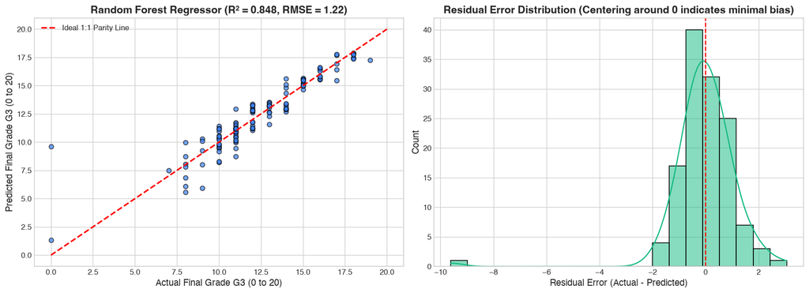

```python
# 7.2 Visualizing Regression Performance: Predicted vs Actual Grades
X_te_r, _, y_te_r, _ = eval_reg_grades
best_reg = models_reg_grades['Random Forest Regressor']
preds_rf_reg = best_reg.predict(X_te_r)

fig, axes = plt.subplots(1, 2, figsize=(15, 5.5))

# 1. Predicted vs Actual Scatter
axes[0].scatter(y_te_r, preds_rf_reg, alpha=0.7, color='#3b82f6', edgecolors='k')
axes[0].plot([0, 20], [0, 20], 'r--', lw=2, label='Ideal 1:1 Parity Line')
axes[0].set_xlabel('Actual Final Grade G3 (0 to 20)')
axes[0].set_ylabel('Predicted Final Grade G3 (0 to 20)')
axes[0].set_title(f"Random Forest Regressor (R² = {r2_score(y_te_r, preds_rf_reg):.3f}, RMSE = {np.sqrt(mean_squared_error(y_te_r, preds_rf_reg)):.2f})", fontweight='bold')
axes[0].legend()

# 2. Residual Distribution
residuals = y_te_r - preds_rf_reg
sns.histplot(residuals, kde=True, ax=axes[1], color='#10b981', bins=20)
axes[1].axvline(0, color='red', linestyle='--', linewidth=1.5)
axes[1].set_xlabel('Residual Error (Actual - Predicted)')
axes[1].set_title('Residual Error Distribution (Centering around 0 indicates minimal bias)', fontweight='bold')

plt.tight_layout()
plt.show()
```

## 8. Feature Importance & Model Interpretability

Interpretability is paramount in educational interventions to provide teachers and counselors with actionable insights into *why* a student is forecasted to struggle.

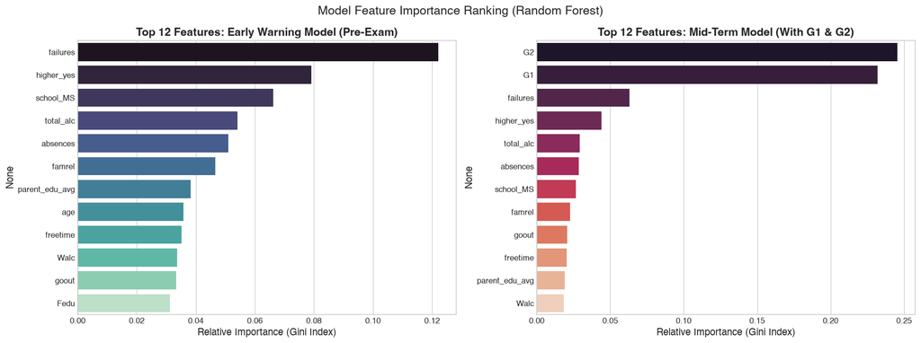

```
Top 5 Early Warning Drivers of Performance:
 1. failures            : 0.1221
 2. higher_yes          : 0.0792
 3. school_MS           : 0.0662
 4. total_alc           : 0.0541
 5. absences            : 0.0511
```

```python
# 8. Feature Importance Analysis
rf_early = models_cls_early['Random Forest']
rf_midterm = models_cls_grades['Random Forest']

imp_early = pd.Series(rf_early.feature_importances_, index=features_early).sort_values(ascending=False).head(12)
imp_midterm = pd.Series(rf_midterm.feature_importances_, index=features_with_grades).sort_values(ascending=False).head(12)

fig, axes = plt.subplots(1, 2, figsize=(16, 6))

sns.barplot(x=imp_early.values, y=imp_early.index, ax=axes[0], palette='mako')
axes[0].set_title('Top 12 Features: Early Warning Model (Pre-Exam)', fontweight='bold')
axes[0].set_xlabel('Relative Importance (Gini Index)')

sns.barplot(x=imp_midterm.values, y=imp_midterm.index, ax=axes[1], palette='rocket')
axes[1].set_title('Top 12 Features: Mid-Term Model (With G1 & G2)', fontweight='bold')
axes[1].set_xlabel('Relative Importance (Gini Index)')

plt.suptitle('Model Feature Importance Ranking (Random Forest)', fontsize=15, y=0.98)
plt.tight_layout()
plt.show()

print("Top 5 Early Warning Drivers of Performance:")
for rank, (feat, score) in enumerate(imp_early.head(5).items(), 1):
    print(f" {rank}. {feat:20s}: {score:.4f}")
```

## 9. Hyperparameter Optimization & Model Selection

```python
# 9. Hyperparameter Optimization with GridSearchCV
param_grid = {
    'n_estimators': [100, 200],
    'max_depth': [6, 10, None],
    'min_samples_split': [2, 5],
    'class_weight': ['balanced', None]
}

X_tr_g, X_te_g, y_tr_g, y_te_g = train_test_split(
    df_encoded[features_with_grades], y_classification,
    test_size=0.20, random_state=42, stratify=y_classification
)

grid_rf = GridSearchCV(
    RandomForestClassifier(random_state=42),
    param_grid,
    cv=5,
    scoring='f1',
    n_jobs=-1
)
grid_rf.fit(X_tr_g, y_tr_g)

best_rf_model = grid_rf.best_estimator_
tuned_preds = best_rf_model.predict(X_te_g)

print(f"✓ Optimal Parameters: {grid_rf.best_params_}")
print(f"✓ Tuned Test Accuracy: {accuracy_score(y_te_g, tuned_preds):.4f}")
print(f"✓ Tuned Test F1-Score: {f1_score(y_te_g, tuned_preds):.4f}")
print(f"✓ Tuned Recall:        {recall_score(y_te_g, tuned_preds):.4f}")
```

```
✓ Optimal Parameters: {'class_weight': None, 'max_depth': 10, 'min_samples_split': 5, 'n_estimators': 200}
✓ Tuned Test Accuracy: 0.9000
✓ Tuned Test F1-Score: 0.9417
✓ Tuned Recall:        0.9545
```

## 10. Model Serialization & Export for Web Application

We serialize the optimal classification model, regression model, data scaler, and metadata to `models/` for consumption by the interactive web application.

```python
# 10. Serialization of Production Artifacts
models_dir = 'models'
os.makedirs(models_dir, exist_ok=True)

# Train production models on full features
scaler = StandardScaler()
X_full = df_encoded[features_with_grades]
scaler.fit(X_full)

# Save Models
joblib.dump(best_rf_model, os.path.join(models_dir, 'best_classification_model.pkl'))
joblib.dump(models_reg_grades['Random Forest Regressor'], os.path.join(models_dir, 'best_regression_model.pkl'))
joblib.dump(scaler, os.path.join(models_dir, 'scaler.pkl'))

# Prepare metadata summary for web app
metadata = {
    'project_title': 'Student Performance Prediction Using Data Science and Machine Learning',
    'student_name': 'Parthiv Abhani',
    'student_prn': '23070521106',
    'subject': 'Data Science',
    'faculty_guide': 'Dr. Smita Singh',
    'dataset': 'UCI Student Performance Dataset (Cortez & Silva, 2008)',
    'total_samples': len(df_por),
    'features_count': len(features_with_grades),
    'best_classification_model': 'Random Forest Classifier',
    'best_regression_model': 'Random Forest Regressor',
    'classification_benchmark': df_classification_comparison.to_dict(orient='records'),
    'regression_benchmark': df_regression_comparison.to_dict(orient='records'),
    'top_features_early': imp_early.to_dict(),
    'top_features_midterm': imp_midterm.to_dict(),
    'pass_threshold': 10
}

with open(os.path.join(models_dir, 'model_metadata.json'), 'w') as f:
    json.dump(metadata, f, indent=2)

# Sample Student Profiles for Web App Testing
sample_students = [
    {
        'id': 'high_achiever',
        'name': 'Elena Vance (High Achiever)',
        'description': 'Diligent student with strong study habits, supportive family, and high academic aspirations.',
        'data': {
            'school': 'GP', 'sex': 'F', 'age': 16, 'address': 'U', 'famsize': 'GT3', 'Pstatus': 'T',
            'Medu': 4, 'Fedu': 4, 'Mjob': 'health', 'Fjob': 'teacher', 'reason': 'reputation',
            'guardian': 'mother', 'traveltime': 1, 'studytime': 4, 'failures': 0, 'schoolsup': 'no',
            'famsup': 'yes', 'paid': 'no', 'activities': 'yes', 'nursery': 'yes', 'higher': 'yes',
            'internet': 'yes', 'romantic': 'no', 'famrel': 5, 'freetime': 3, 'goout': 2,
            'Dalc': 1, 'Walc': 1, 'health': 5, 'absences': 2, 'G1': 16, 'G2': 17
        }
    },
    {
        'id': 'at_risk',
        'name': 'Lucas Santos (At-Risk Profile)',
        'description': 'Student with multiple past failures, high absenteeism, low study time, and elevated weekend alcohol.',
        'data': {
            'school': 'MS', 'sex': 'M', 'age': 18, 'address': 'R', 'famsize': 'LE3', 'Pstatus': 'A',
            'Medu': 1, 'Fedu': 1, 'Mjob': 'at_home', 'Fjob': 'other', 'reason': 'course',
            'guardian': 'other', 'traveltime': 3, 'studytime': 1, 'failures': 2, 'schoolsup': 'no',
            'famsup': 'no', 'paid': 'no', 'activities': 'no', 'nursery': 'no', 'higher': 'no',
            'internet': 'no', 'romantic': 'yes', 'famrel': 2, 'freetime': 4, 'goout': 5,
            'Dalc': 3, 'Walc': 5, 'health': 3, 'absences': 18, 'G1': 7, 'G2': 8
        }
    },
    {
        'id': 'average_hardworking',
        'name': 'Sofia Carvalho (Average Resilient)',
        'description': 'Moderate baseline learner making steady progress through structured study and family support.',
        'data': {
            'school': 'GP', 'sex': 'F', 'age': 17, 'address': 'U', 'famsize': 'GT3', 'Pstatus': 'T',
            'Medu': 2, 'Fedu': 3, 'Mjob': 'services', 'Fjob': 'services', 'reason': 'home',
            'guardian': 'father', 'traveltime': 2, 'studytime': 2, 'failures': 0, 'schoolsup': 'no',
            'famsup': 'yes', 'paid': 'yes', 'activities': 'yes', 'nursery': 'yes', 'higher': 'yes',
            'internet': 'yes', 'romantic': 'no', 'famrel': 4, 'freetime': 3, 'goout': 3,
            'Dalc': 1, 'Walc': 2, 'health': 4, 'absences': 6, 'G1': 12, 'G2': 12
        }
    }
]

with open(os.path.join(models_dir, 'sample_students.json'), 'w') as f:
    json.dump(sample_students, f, indent=2)

print("✓ All production models and metadata successfully exported to models/")
```

```
✓ All production models and metadata successfully exported to models/
```

## 11. Conclusions, Academic Insights & Recommendations

- **First-Month Early Flagging:** Deploy the Early Warning model within the first 30 days of the academic calendar to flag students with $\ge 1$ past failure and low study time for academic mentoring.
- **Attendance Guardrails:** Trigger automatic counseling when a student accumulates more than 6 unexcused absences.
- **Targeted Remediation:** Pair at-risk students with peer tutoring programs before midterms to bolster baseline competencies before Period 1 ($G1$).